# IODS course project

### Describing and interpreting the outputs, commenting on the distributions of the variables and the relationships between them:

- crim (per capita crime rate by town)- the mean (3.61352)and median (0.25651) are low, but there are probably a few cases where the crime rate is very high as the range is from 0.00632 to 88.97620
- zn (proportion of residential land zoned for lots over 25,000 sq.ft.)The range is from 0 to 100. Mean is 11.36 and median 0 so most of the answers are in the lower range of the scale
- indus (proportion of non-retail business acres per town.)THe range is from 0.26 to 27.74. Mean and median are close to eachother but skewed a bit towards lower end of the range.
- chas (Charles River dummy variable (= 1 if tract bounds river; 0 otherwise).) Mean: 0.06917, meaning it is more common that tract does not bound river *nox (nitrogen oxides concentration (parts per 10 million).)The range is from 0.3850 to 0.8710 and mean is 0.5547, median almost the same. Slightly skewed towards lower nitrogen concentration.
- rm (average number of rooms per dwelling.)Range: 3.561-8.780, mean 6.285, median almost the same.
- age (proportion of owner-occupied units built prior to 1940.)Range 2.90-100. Mean: 68.57, the first quartile is also over 45, so most cities seem to have a rather high proportion of owner-occupied units built prior to 1940.
- dis (weighted mean of distances to five Boston employment centres.)Range 1.130-12.127, mean and median a bit over 3, so most cities are quite close to the employment centres
- rad (index of accessibility to radial highways.)Range 1-24. Mean 9.549, Median 5. Skewed towards the lower range of the index.
- tax (full-value property-tax rate per $10,000.) Range 187-711, Mean 408.2, Quite equally distrebuted
- black1000(Bk - 0.63)^21000(Bk−0.63) (2 where BkBk is the proportion of blacks by town.) Range 0.32 -396.9. Already first quartile is 375.38 so there are only a few findings at the lower range of the scale.
- lstat (lower status of the population (percent).)Range 1,73-37.97. 3rd quartile is 16.95 so most of the findings are at the lower range of the scale
- medv (median value of owner-occupied homes in $1000s.)Range: 5-50, mean 22.53 - quite equally distributed

Relationships between the variables:

The highest positive correlation is between rad and tax (better access to radial highways is correlated with higher property tax rate, makes sense!). High negative correlations are between age and dis, lstat and med, dis and nox (this has highest correlation - the farther away you are from employment centers the less nitroxide oxid there is - makes sense!) as well as indus and dis.

## 4. Standardizing the dataset, printing out summaries of the scaled data

```r
boston_scaled <- scale(Boston)
summary(boston_scaled)
```

```
##       crim                 zn               indus              chas
##  Min.   :-0.419367   Min.   :-0.48724   Min.   :-1.5563   Min.   :-0.2723
##  1st Qu.:-0.410563   1st Qu.:-0.48724   1st Qu.:-0.8668   1st Qu.:-0.2723
##  Median :-0.390280   Median :-0.48724   Median :-0.2109   Median :-0.2723
##  Mean   : 0.000000   Mean   : 0.00000   Mean   : 0.0000   Mean   : 0.0000
##  3rd Qu.: 0.007389   3rd Qu.: 0.04872   3rd Qu.: 1.0150   3rd Qu.:-0.2723
##  Max.   : 9.924110   Max.   : 3.80047   Max.   : 2.4202   Max.   : 3.6648
##       nox                rm               age               dis
##  Min.   :-1.4644   Min.   :-3.8764   Min.   :-2.3331   Min.   :-1.2658
##  1st Qu.:-0.9121   1st Qu.:-0.5681   1st Qu.:-0.8366   1st Qu.:-0.8049
##  Median :-0.1441   Median :-0.1084   Median : 0.3171   Median :-0.2790
##  Mean   : 0.0000   Mean   : 0.0000   Mean   : 0.0000   Mean   : 0.0000
##  3rd Qu.: 0.5981   3rd Qu.: 0.4823   3rd Qu.: 0.9059   3rd Qu.: 0.6617
##  Max.   : 2.7296   Max.   : 3.5515   Max.   : 1.1164   Max.   : 3.9566
##       rad               tax             ptratio            black
##  Min.   :-0.9819   Min.   :-1.3127   Min.   :-2.7047   Min.   :-3.9033
##  1st Qu.:-0.6373   1st Qu.:-0.7668   1st Qu.:-0.4876   1st Qu.: 0.2049
##  Median :-0.5225   Median :-0.4642   Median : 0.2746   Median : 0.3808
##  Mean   : 0.0000   Mean   : 0.0000   Mean   : 0.0000   Mean   : 0.0000
##  3rd Qu.: 1.6596   3rd Qu.: 1.5294   3rd Qu.: 0.8058   3rd Qu.: 0.4332
##  Max.   : 1.6596   Max.   : 1.7964   Max.   : 1.6372   Max.   : 0.4406
##      lstat              medv
##  Min.   :-1.5296   Min.   :-1.9063
##  1st Qu.:-0.7986   1st Qu.:-0.5989
##  Median :-0.1811   Median :-0.1449
##  Mean   : 0.0000   Mean   : 0.0000
##  3rd Qu.: 0.6024   3rd Qu.: 0.2683
##  Max.   : 3.5453   Max.   : 2.9865
```

```r
class(boston_scaled)
```

```
## [1] "matrix" "array"
```

```r
boston_scaled <- as.data.frame(boston_scaled)
```

The standard score or Z-score is the number of standard deviations by which the value of a raw score is above or below the mean value of what is being observed or measured. Scale function does this -> the variables become more similar and easier to compare

### Creating a categorical variable

```r
boston_scaled$crim <- as.numeric(boston_scaled$crim)
summary(boston_scaled$crim)
```

```
##      Min.   1st Qu.    Median      Mean   3rd Qu.      Max.
## -0.419367 -0.410563 -0.390280  0.000000  0.007389  9.924110
```

```r
bins <- quantile(boston_scaled$crim)
bins
```

```
##           0%          25%          50%          75%         100%
## -0.419366929 -0.410563278 -0.390280295  0.007389247  9.924109610
```

```r
crime <- cut(boston_scaled$crim, breaks = bins, include.lowest = TRUE, labels = c("low", "med_low", "med_high", "high"))
table(crime)
```

```
## crime
##      low  med_low med_high     high
##      127      126      126      127
```

```r
boston_scaled <- dplyr::select(boston_scaled, -crim)
boston_scaled <- data.frame(boston_scaled, crime)
```

### Dividing the dataset to train and test sets

```r
n <- nrow(boston_scaled)
ind <- sample(n,  size = n * 0.8)
train <- boston_scaled[ind,]
test <- boston_scaled[-ind,]
correct_classes <- test$crime

test <- dplyr::select(test, -crime)
correct_classes
```

```
##   [1] low      med_low  med_high med_high med_low  low      low      low
##   [9] low      low      low      med_low  med_low  low      low      low
##  [17] low      low      low      low      med_low  med_low  med_high med_low
##  [25] med_low  low      med_low  med_low  med_high high     med_high med_high
##  [33] med_high med_high low      med_low  low      low      med_low  med_low
##  [41] low      med_low  med_low  med_high med_high med_low  med_low  med_high
##  [49] med_high med_low  low      low      low      med_low  low      low
##  [57] low      med_high med_high med_high med_low  med_high med_low  low
##  [65] low      low      low      low      low      med_low  high     high
##  [73] high     high     high     high     high     high     high     high
##  [81] high     high     high     high     high     high     high     high
##  [89] high     high     high     high     high     high     high     high
##  [97] high     high     high     med_high med_low  low
## Levels: low med_low med_high high
```

## 5. Fitting the linear discriminant analysis on the train set.

```r
lda.fit <- lda(crime ~ ., data = train)
lda.fit
```

```
## Call:
## lda(crime ~ ., data = train)
##
## Prior probabilities of groups:
##       low   med_low  med_high      high
## 0.2351485 0.2549505 0.2698020 0.2400990
##
## Group means:
##                   zn      indus        chas        nox         rm        age
## low       1.05949609 -0.9299874 -0.06511327 -0.8959657  0.4844854 -0.9582198
## med_low  -0.07990739 -0.3503290 -0.11943197 -0.5908215 -0.1170014 -0.3818861
## med_high -0.38339098  0.1992183  0.26947372  0.3664287  0.1094969  0.4318573
## high     -0.48724019  1.0149946 -0.06938576  1.0705014 -0.3898023  0.8178297
##                 dis        rad        tax     ptratio      black       lstat
## low       0.9114957 -0.6893143 -0.7349641 -0.43844882  0.3790640 -0.81138019
## med_low   0.3732994 -0.5414397 -0.4717596 -0.09291904  0.3590366 -0.14735716
## med_high -0.3631822 -0.4150132 -0.3078760 -0.26380799  0.1064713  0.04413821
## high     -0.8447342  1.6596029  1.5294129  0.80577843 -0.7840293  0.88823155
##                medv
## low       0.6009711
## med_low   0.0023445
## med_high  0.1680067
## high     -0.7726347
##
## Coefficients of linear discriminants:
##                   LD1          LD2         LD3
## zn       0.0996626760  0.796572826 -1.00642300
## indus    0.0469441822 -0.369277996  0.05285838
## chas    -0.0739725624 -0.063822438 -0.03953101
## nox      0.2567667140 -0.663465119 -1.35587346
## rm      -0.0873522682 -0.141089306 -0.09119694
## age      0.2575039178 -0.381821474 -0.17284578
## dis     -0.0978798773 -0.369008628  0.06235971
## rad      3.3948189977  0.822111048 -0.10633764
## tax      0.0006746408  0.127742062  0.76768774
## ptratio  0.1370494737  0.052234845 -0.41122096
## black   -0.1738395729  0.009595504  0.20179917
## lstat    0.2055612275 -0.283843755  0.33399716
## medv     0.1803115749 -0.409574885 -0.33306416
##
## Proportion of trace:
##    LD1    LD2    LD3
## 0.9438 0.0426 0.0136
```

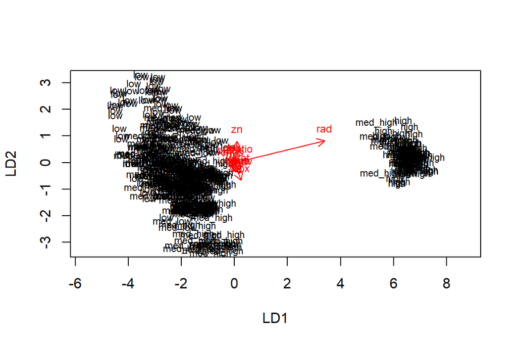

```r
lda.arrows <- function(x, myscale = 1, arrow_heads = 0.1, color = "red", tex = 0.75, choices = c(1,2)){
  heads <- coef(x)
  arrows(x0 = 0, y0 = 0,
         x1 = myscale * heads[,choices[1]],
         y1 = myscale * heads[,choices[2]], col=color, length = arrow_heads)
  text(myscale * heads[,choices], labels = row.names(heads),
       cex = tex, col=color, pos=3)
}

classes <- as.numeric(train$crime)

plot(lda.fit, dimen = 2)
lda.arrows(lda.fit, myscale = 1)
```

## 6. Saving the crime categories and predicting the classes with the LDA model

I had saved the crime categories already before

```r
lda.pred <- predict(lda.fit, newdata = test)
table(correct = correct_classes, predicted = lda.pred$class)
```

```
##           predicted
## correct    low med_low med_high high
##   low       15      15        2    0
##   med_low    2      15        6    0
##   med_high   0       6       10    1
##   high       0       0        1   29
```

The model mostly predicts correctly